# UK Electricity Generation

covid 19 lockdown v1.0

Ben Anderson

Last run at: 2020-05-16 23:29:27

# 1 About

## 1.1 Citation

If you wish to use any of the material from this report please cite as:

- Ben Anderson (2020) *UK Electricity Generation: covid 19 lockdown v1.0*, [Centre for Sustainability](http://www.otago.ac.nz/centre-sustainability/), University of Otago: Dunedin.

This work is (c) 2020 the authors. Usage rights are specified in the License section (1.4).

## 1.2 Report circulation

- Public – this report is intended for publication.

## 1.3 Code

All code used to create this report is available from:

- https://github.com/CfSOtago/gridCarbon

## 1.4 License

This work is made available under the Creative Commons [Attribution-ShareAlike 4.0 International (CC BY-SA 4.0) License](https://creativecommons.org/licenses/by-sa/4.0/).

This means you are free to:

- *Share* — copy and redistribute the material in any medium or format
- *Adapt* — remix, transform, and build upon the material for any purpose, even commercially.

Under the following terms:

- *Attribution* — You must give appropriate credit, provide a link to the license, and indicate if changes were made. You may do so in any reasonable manner, but not in any way that suggests the licensor endorses you or your use.
- *ShareAlike* — If you remix, transform, or build upon the material, you must distribute your contributions under the same license as the original.
- *No additional restrictions* — You may not apply legal terms or technological measures that legally restrict others from doing anything the license permits.

**Notices:**

- You do not have to comply with the license for elements of the material in the public domain or where your use is permitted by an applicable exception or limitation.
- No warranties are given. The license may not give you all of the permissions necessary for your intended use. For example, other rights such as publicity, privacy, or moral rights may limit how you use the material.

For the avoidance of doubt and explanation of terms please refer to the full [license notice](https://creativecommons.org/licenses/by-sa/4.0/) and [legal code](https://creativecommons.org/licenses/by-sa/4.0/legalcode).

## 1.5 History

You may not be reading the most recent version of this report. Please check:

- the github [R code repository](https://github.com/CfSOtago/gridCarbon);
- our [issues list](https://github.com/CfSOtago/gridCarbon/issues) for any unfixed problems;
- our [project publictions](https://cfsotago.github.io/gridCarbon/);

We do not ‘support’ the code but if you notice a problem please check the issues on our [repo](https://github.com/CfSOtago/gridCarbon) and if it doesn’t already exist, please open a new one. * this [report’s edit history](https://github.com/CfSOtago/gridCarbon/commits/master/dataAnalysis/)

## 1.6 Support

This work was supported by:

- The [University of Otago](https://www.otago.ac.nz/);
- [SPATIALEC](http://www.energy.soton.ac.uk/tag/spatialec/) - a [Marie Skłodowska-Curie Global Fellowship](http://ec.europa.eu/research/mariecurieactions/about-msca/actions/if/index_en.htm) based at the University of Otago’s [Centre for Sustainability](http://www.otago.ac.nz/centre-sustainability/staff/otago673896.html) (2017-2019) & the University of Southampton’s Sustainable Energy Research Group (2019-2020).
- The European Union via [SPATIALEC](http://www.energy.soton.ac.uk/tag/spatialec/), a Marie Skłodowska-Curie [Global Fellowship](https://ec.europa.eu/research/mariecurieactions/actions/individual-fellowships_en) based at the University of Otago’s [Centre for Sustainability](http://www.otago.ac.nz/centre-sustainability/staff/otago673896.html) (2017-2019) & the University of Southampton’s [Sustainable Energy Research Group](http://www.otago.ac.nz/centre-sustainability/staff/otago673896.html) (2019-2020) (Anderson)

# 2 Introduction

Fortunately the UK Electricity System Operator publishes half-hourly generation data which includes both power generation (and thus ‘demand’) by fuels and also includes a per-kWh carbon intensity for the enrgy produced per half-hour. We use this data to explore the following research questions:

- To what extent has electricty demand shown deviation from ‘normal’ demand patterns during the lockdown period?
- Has the composition of fuel sources supplying electriicty changed during this period?
- Has the lockdown changed greenhouse-gas emissions associated with electriicty generation?

# 3 Data

## 3.1 Grid generation data

Essentially ‘grid’ generation from major power stations of various kinds. Data downloaded from `https://data.nationalgrideso.com/carbon-intensity1/historic-generation-mix/r/historic_gb_generation_mix` and pre-processed.

Table 3.1: Grid gen data (first 6 rows)

| DATETIME | year | rDateTimeUTC | GENERATION | CARBON_INTENSITY |
| --- | --- | --- | --- | --- |
| 2016-01-01 00:00:00 | 2016 | 2016-01-01 00:00:00 | 28789 | 249 |
| 2016-01-01 00:30:00 | 2016 | 2016-01-01 00:30:00 | 29372 | 262 |
| 2016-01-01 01:00:00 | 2016 | 2016-01-01 01:00:00 | 29468 | 275 |
| 2016-01-01 01:30:00 | 2016 | 2016-01-01 01:30:00 | 28745 | 277 |
| 2016-01-01 02:00:00 | 2016 | 2016-01-01 02:00:00 | 27737 | 278 |
| 2016-01-01 02:30:00 | 2016 | 2016-01-01 02:30:00 | 27045 | 277 |

Table 3.2: Mean half hourly power (MW) and carbon intensity (CO2e) by year - note that 2020 is incomplete

| year | meanHalfHourlyMW | meanCI | nObs |
| --- | --- | --- | --- |
| 2017 | 33946.25 | 262.7744 | 17520 |
| 2018 | 33878.68 | 234.9804 | 17520 |
| 2019 | 33269.86 | 214.0823 | 17520 |
| 2020 | 33119.47 | 188.5371 | 6286 |

## 3.2 Embedded generation data

Essentially ‘non-grid’ generation from solar photovoltaic and small scale wind which is ‘embedded’ - i.e. non-grid connected as it is connected ‘downstream’ of the grid exit points. We are not entirely sure if this is accounted for in the grid dataset or not.

> We have not yet found a source of this data.

> For now embedded generation data is probably *not* included in the following analysis but we would expect it to depress grid demand when the sun is shining and the wind is blowing.

# 4 Analysis

In this section we analyse changes in electricity demand during the UK Covid-19 lockdown via analysis of the generation data.

## 4.1 Deviation from ‘normal’

Several [articles](https://theconversation.com/we-analysed-electricity-demand-and-found-coronavirus-has-turned-weekdays-into-weekends-134606?utm_source=twitter&utm_medium=bylinetwitterbutton) and [analyses](https://twitter.com/DrIAGWilson/status/1255100828781883394) have suggested that demand (and thus generation) patterns have shifted so that [weekdays have become more like weekends](http://www.ukerc.ac.uk/news/covid-lockdown-electricity-demand.html).

Figure 4.1 shows total half-hourly generation since 2020-03-01. Overall generation has fallen as we would expect given the season (less heating and lighting required) and weekdays are indeed less easy to distinguish from weekends.

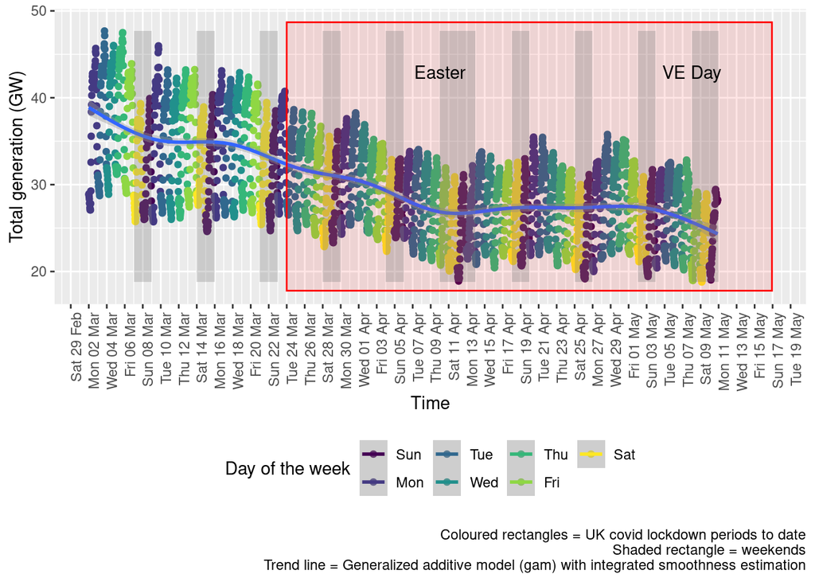

Figure 4.1: Half-hourly generation, UK (recent)

Figure 4.2 shows the daily generation profiles over time for each day of the week. Clearly the shapes are both reducing in magnitude (seasonal and lockdown effects) and also converging in shape.

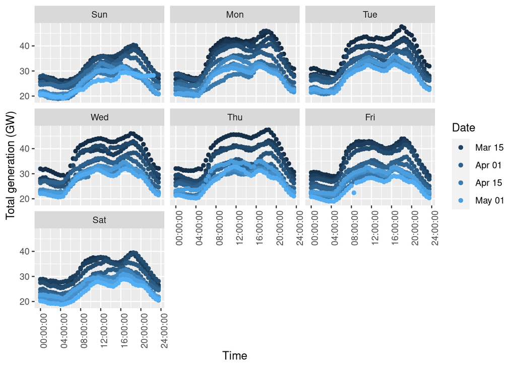

Figure 4.2: Half-hourly generation, UK (recent)

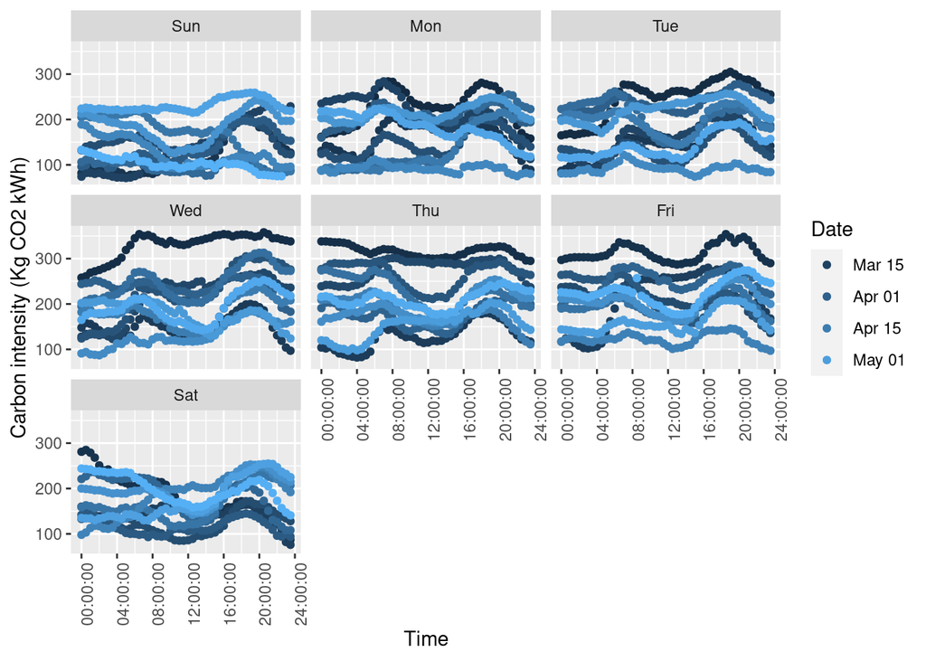

Figure 4.4 shows half-hourly carbon intensity since 2020-03-01. As we might expect this is much more variable largely due to the contribution made by wind generation.

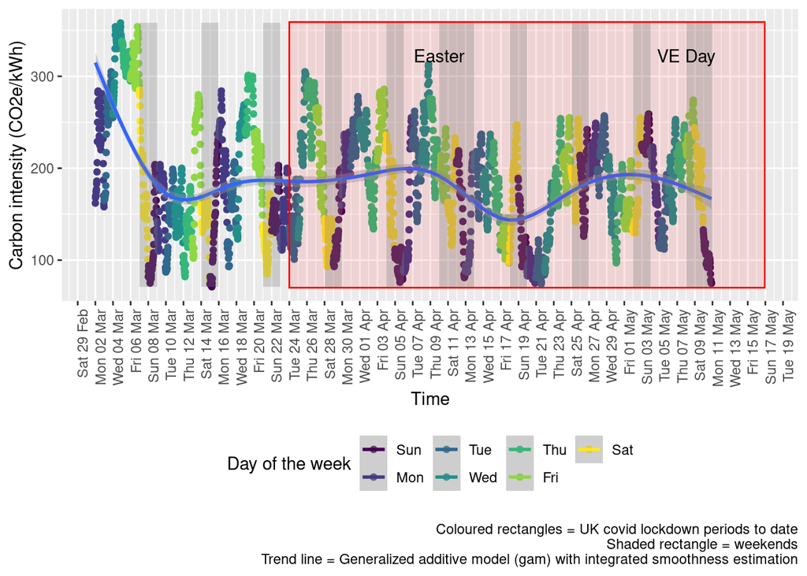

Figure 4.4: Half-hourly carbon intensity, UK (recent)

Figure 4.5 shows the most recent mean half-hourly GW compared to the same day in previous years. We have shifted the dates for the comparison years to ensure that weekdays and weekends line up. Note that this plot shows daily means with no indications of variance. Visible differences are therefore purely indicative at this stage. Nevertheless it is clear that 2020 is a different generation shape to the average of the previous years. Lockdown has clearly amplified the sesonal trend.

> Beware temperature differences

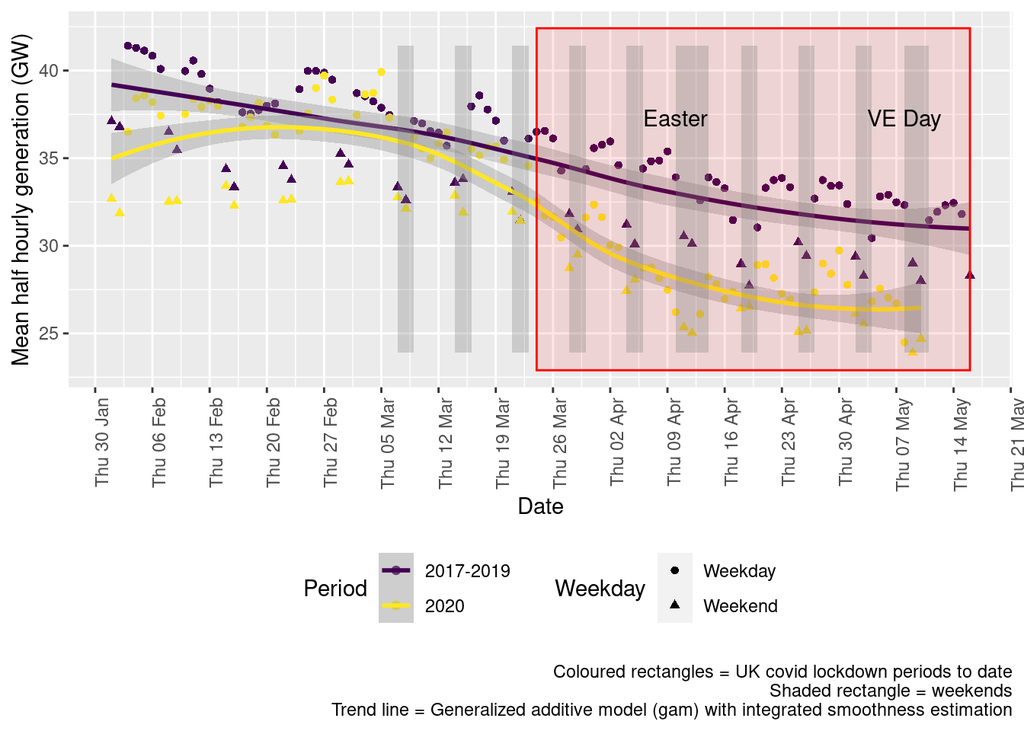

Figure 4.5: Comparative daily mean half-hour generation levels 2020 vs 2017-2019

Figure 4.6 shows the percentage difference between the mean half-hourly generation per day in 2020 and the 2017-2019 average for the same day. As we can see 2020 was already slightly lower than previous years but there appears to be a substantial lockdown effect especially on weekdays as we would expect.

```
## [1] "Max drop %:-24"
```

```
## [1] "Max increase %:5"
```

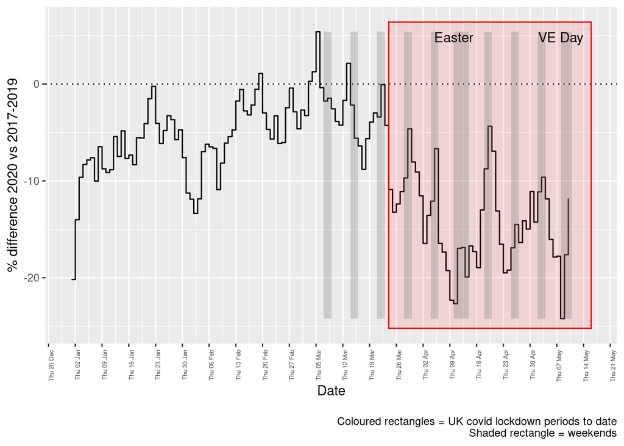

Figure 4.6: Percentage difference in mean generation levels 2020 vs 2017-2019

Figure 4.7 shows the percentage difference between the mean half-hourly carbon intensity per day in 2020 and the 2017-2019 average for the same day. As expected, 2020 was already considerably lower than the average of previous years but this is not necessarily sustained through lockdown although the affects of weather on solar and wind availability need to be taken in to account.

```
## [1] "Max drop %:-60"
```

```
## [1] "Max increase %:26"
```

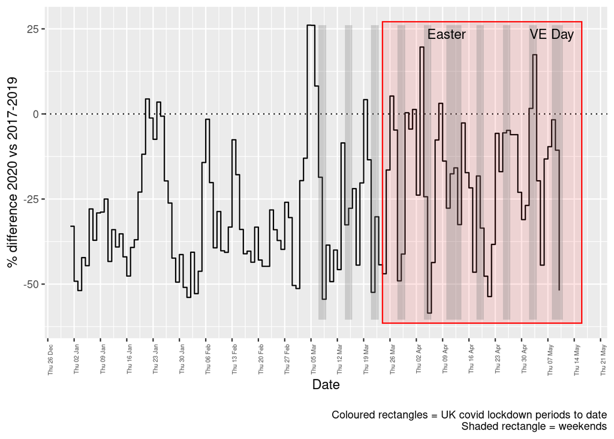

Figure 4.7: Percentage difference in mean carbon intensity levels 2020 vs 2017-2019

# 5 Summary (to date)

# 6 Annexes

## 6.1 Grid generation data

Table 6.1: Data summary

| Name | gridGenDT |
| --- | --- |
| Number of rows | 76414 |
| Number of columns | 40 |
| _______________________ |  |
| Column type frequency: |  |
| character | 2 |
| Date | 2 |
| factor | 2 |
| numeric | 33 |
| POSIXct | 1 |
| ________________________ |  |
| Group variables | None |

**Variable type: character**

| skim_variable | n_missing | complete_rate | min | max | empty | n_unique | whitespace |
| --- | --- | --- | --- | --- | --- | --- | --- |
| DATETIME | 0 | 1 | 19 | 19 | 0 | 76414 | 0 |
| rDateTime | 0 | 1 | 20 | 20 | 0 | 76414 | 0 |

**Variable type: Date**

| skim_variable | n_missing | complete_rate | min | max | median | n_unique |
| --- | --- | --- | --- | --- | --- | --- |
| obsDate | 10 | 1 | 2016-01-01 | 2020-05-10 | 2018-03-06 | 1592 |
| date2020 | 10 | 1 | 2020-01-01 | 2020-12-31 | 2020-06-15 | 366 |

**Variable type: factor**

| skim_variable | n_missing | complete_rate | ordered | n_unique | top_counts |
| --- | --- | --- | --- | --- | --- |
| rMonth | 10 | 1 | TRUE | 12 | Jan: 7440, Mar: 7430, Apr: 7200, Feb: 6816 |
| day2020 | 10 | 1 | TRUE | 7 | Wed: 13102, Thu: 12190, Fri: 11040, Tue: 10846 |

**Variable type: numeric**

| skim_variable | n_missing | complete_rate | mean | sd | p0 | p25 | p50 | p75 | p100 | hist |
| --- | --- | --- | --- | --- | --- | --- | --- | --- | --- | --- |
| GAS | 0 | 1 | 13286.71 | 5239.67 | 2187.0 | 9269.25 | 13075.00 | 17223.00 | 27472.00 | ▃▇▇▅▁ |
| COAL | 0 | 1 | 1911.88 | 2391.23 | 0.0 | 249.00 | 931.00 | 2660.75 | 14724.00 | ▇▂▁▁▁ |
| NUCLEAR | 0 | 1 | 6889.78 | 991.03 | 3705.0 | 6262.00 | 6972.00 | 7670.00 | 8859.00 | ▁▂▆▇▃ |
| WIND | 0 | 1 | 5313.45 | 3705.27 | 0.0 | 2298.00 | 4541.00 | 7634.00 | 17129.00 | ▇▆▃▂▁ |
| HYDRO | 0 | 1 | 418.57 | 255.17 | 0.0 | 211.00 | 385.00 | 590.00 | 1403.00 | ▇▇▅▂▁ |
| IMPORTS | 0 | 1 | 2528.81 | 952.80 | 0.0 | 1960.00 | 2716.00 | 3116.00 | 4884.00 | ▂▅▇▇▂ |
| BIOMASS | 0 | 1 | 1107.44 | 1052.64 | 0.0 | 0.00 | 1240.00 | 2045.00 | 3204.00 | ▇▂▃▃▂ |
| OTHER | 0 | 1 | 743.81 | 827.56 | 0.0 | 88.00 | 143.00 | 1483.00 | 2173.00 | ▇▁▁▂▃ |
| SOLAR | 0 | 1 | 1279.63 | 1989.40 | 0.0 | 0.00 | 9.00 | 2070.00 | 9680.00 | ▇▂▁▁▁ |
| STORAGE | 0 | 1 | 266.64 | 328.11 | 0.0 | 0.00 | 178.00 | 394.00 | 2394.00 | ▇▁▁▁▁ |
| GENERATION | 0 | 1 | 33746.72 | 7009.20 | 18708.0 | 28350.00 | 33599.50 | 38649.75 | 53427.00 | ▃▇▇▅▁ |
| CARBON_INTENSITY | 0 | 1 | 247.49 | 74.84 | 57.0 | 197.00 | 242.00 | 292.00 | 511.00 | ▂▇▇▂▁ |
| LOW_CARBON | 0 | 1 | 15008.87 | 4148.93 | 6755.0 | 11810.00 | 14490.00 | 17774.00 | 30746.00 | ▅▇▅▂▁ |
| ZERO_CARBON | 0 | 1 | 13901.42 | 3827.80 | 5164.0 | 10883.25 | 13523.00 | 16528.00 | 28473.00 | ▃▇▆▂▁ |
| RENEWABLE | 0 | 1 | 7011.64 | 4036.18 | 125.0 | 3807.00 | 6478.00 | 9666.00 | 23118.00 | ▇▇▅▁▁ |
| FOSSIL | 0 | 1 | 15198.59 | 6683.44 | 2187.0 | 10123.00 | 14461.00 | 19359.00 | 36842.00 | ▅▇▆▂▁ |
| GAS_perc | 0 | 1 | 38.55 | 10.83 | 6.6 | 31.20 | 40.10 | 46.80 | 65.30 | ▁▃▇▇▁ |
| COAL_perc | 0 | 1 | 5.04 | 5.64 | 0.0 | 0.90 | 3.00 | 7.30 | 30.20 | ▇▂▁▁▁ |
| NUCLEAR_perc | 0 | 1 | 21.33 | 5.55 | 9.7 | 17.20 | 20.50 | 24.60 | 43.10 | ▃▇▅▁▁ |
| WIND_perc | 0 | 1 | 16.10 | 11.33 | 0.0 | 7.00 | 13.60 | 22.80 | 58.30 | ▇▆▃▁▁ |
| HYDRO_perc | 0 | 1 | 1.21 | 0.68 | 0.0 | 0.70 | 1.10 | 1.70 | 4.20 | ▇▇▅▁▁ |
| IMPORTS_perc | 0 | 1 | 7.85 | 3.28 | 0.0 | 5.70 | 8.10 | 10.20 | 18.90 | ▂▆▇▃▁ |
| BIOMASS_perc | 0 | 1 | 3.38 | 3.28 | 0.0 | 0.00 | 3.60 | 6.10 | 15.90 | ▇▅▃▁▁ |
| OTHER_perc | 0 | 1 | 2.27 | 2.57 | 0.0 | 0.30 | 0.50 | 4.60 | 10.50 | ▇▂▂▁▁ |
| SOLAR_perc | 0 | 1 | 3.57 | 5.66 | 0.0 | 0.00 | 0.00 | 5.60 | 31.70 | ▇▂▁▁▁ |
| STORAGE_perc | 0 | 1 | 0.71 | 0.84 | 0.0 | 0.00 | 0.50 | 1.10 | 6.10 | ▇▂▁▁▁ |
| GENERATION_perc | 0 | 1 | 100.00 | 0.00 | 100.0 | 100.00 | 100.00 | 100.00 | 100.00 | ▁▁▇▁▁ |
| LOW_CARBON_perc | 0 | 1 | 45.58 | 12.94 | 16.4 | 35.90 | 44.00 | 53.70 | 87.90 | ▂▇▆▂▁ |
| ZERO_CARBON_perc | 0 | 1 | 42.20 | 11.99 | 15.5 | 33.30 | 40.70 | 49.80 | 85.10 | ▂▇▅▂▁ |
| RENEWABLE_perc | 0 | 1 | 20.88 | 11.78 | 0.5 | 11.60 | 19.10 | 28.30 | 66.20 | ▆▇▅▂▁ |
| FOSSIL_perc | 0 | 1 | 43.59 | 12.80 | 7.7 | 34.80 | 44.40 | 52.90 | 76.70 | ▁▅▇▆▁ |
| year | 0 | 1 | 2017.70 | 1.27 | 2016.0 | 2017.00 | 2018.00 | 2019.00 | 2020.00 | ▇▇▇▇▃ |
| decimalDate | 10 | 1 | 2018.18 | 1.26 | 2016.0 | 2017.08 | 2018.18 | 2019.27 | 2020.36 | ▇▇▇▇▇ |

**Variable type: POSIXct**

| skim_variable | n_missing | complete_rate | min | max | median | n_unique |
| --- | --- | --- | --- | --- | --- | --- |
| rDateTimeUTC | 10 | 1 | 2016-01-01 | 2020-05-10 22:30:00 | 2018-03-06 22:45:00 | 76404 |

## 6.2 Conversion factors

# 7 Runtime

Analysis completed in 17.79 seconds ( 0.3 minutes) using knitr in [RStudio](http://www.rstudio.com) with R version 3.6.0 (2019-04-26) running on x86_64-redhat-linux-gnu.

# 8 R environment

## 8.1 R packages used

- base R (R Core Team 2016)
- bookdown (Xie 2016a)
- data.table (Dowle et al. 2015)
- drake (Landau 2019)
- ggplot2 (Wickham 2009)
- kableExtra (Zhu 2018)
- knitr (Xie 2016b)
- lubridate (Grolemund and Wickham 2011)
- rmarkdown (Allaire et al. 2018)

# References

Allaire, JJ, Yihui Xie, Jonathan McPherson, Javier Luraschi, Kevin Ushey, Aron Atkins, Hadley Wickham, Joe Cheng, and Winston Chang. 2018. *Rmarkdown: Dynamic Documents for R*. https://CRAN.R-project.org/package=rmarkdown.

Dowle, M, A Srinivasan, T Short, S Lianoglou with contributions from R Saporta, and E Antonyan. 2015. *Data.table: Extension of Data.frame*. https://CRAN.R-project.org/package=data.table.

Grolemund, Garrett, and Hadley Wickham. 2011. “Dates and Times Made Easy with lubridate.” *Journal of Statistical Software* 40 (3): 1–25. http://www.jstatsoft.org/v40/i03/.

Khan, Imran, Michael W. Jack, and Janet Stephenson. 2018. “Analysis of Greenhouse Gas Emissions in Electricity Systems Using Time-Varying Carbon Intensity.” *Journal of Cleaner Production* 184 (May): 1091–1101. doi:10.1016/j.jclepro.2018.02.309.

Landau, William Michael. 2019. *Drake: A Pipeline Toolkit for Reproducible Computation at Scale*. https://CRAN.R-project.org/package=drake.

R Core Team. 2016. *R: A Language and Environment for Statistical Computing*. Vienna, Austria: R Foundation for Statistical Computing. https://www.R-project.org/.

Staffell, Iain. 2017. “Measuring the Progress and Impacts of Decarbonising British Electricity.” *Energy Policy* 102 (March): 463–75. doi:10.1016/j.enpol.2016.12.037.

Wickham, Hadley. 2009. *Ggplot2: Elegant Graphics for Data Analysis*. Springer-Verlag New York. http://ggplot2.org.

Xie, Yihui. 2016a. *Bookdown: Authoring Books and Technical Documents with R Markdown*. Boca Raton, Florida: Chapman; Hall/CRC. https://github.com/rstudio/bookdown.

———. 2016b. *Knitr: A General-Purpose Package for Dynamic Report Generation in R*. https://CRAN.R-project.org/package=knitr.

Zhu, Hao. 2018. *KableExtra: Construct Complex Table with ’Kable’ and Pipe Syntax*. https://CRAN.R-project.org/package=kableExtra.